# Stats 744: hw2

Daniella Lato

20/09/2019

## Original Graph

The following homework assignment is about Jia You’s online graphic about vaccines which can be found [here](https://www.sciencemag.org/news/2017/04/here-s-visual-proof-why-vaccines-do-more-good-harm).

## What question is this graphic trying to answer?

I believe that this graphic is trying to answer the question: Do vaccines work? I think that the author is trying to show that after a vaccine has been licensed for a number of diseases, the number of reported cases (in the U.S.) decreases. Hence, matching the title of the graphic that “visual proof of why vaccines do more good than harm”.

BMB: yes, although the title is a little weird, since it doesn’t actually show anything about (potential) harm caused by vaccines …

## Create 2 new plots with the same data

Read in and prep the data.

```r
vac_dat <- read.csv("vaccine_data_online.csv")
#now re-ordering the data
vac_dat$disease <- with(vac_dat, reorder(disease, cases, FUN = mean))
vac_dat$disease <- with(vac_dat, reorder(disease, cases, FUN =function(x) -x[1]))
## BMB: first line is overwritten by second?
#make dataframe for vaccination licenceing
#to be used in later graphs
vac_l <- vac_dat[which(vac_dat$vaccine != "FALSE"),]
vac_l <- vac_l[,c(3,4)] ## BMB: try not to index columns by number
vac_l <- vac_l[!duplicated(vac_l$disease),]
```

### Graph 1:

The first graph shows the total number of reported cases for each disease in the U.S. The black vertical lines show the year that the vaccine was licensed for each disease.

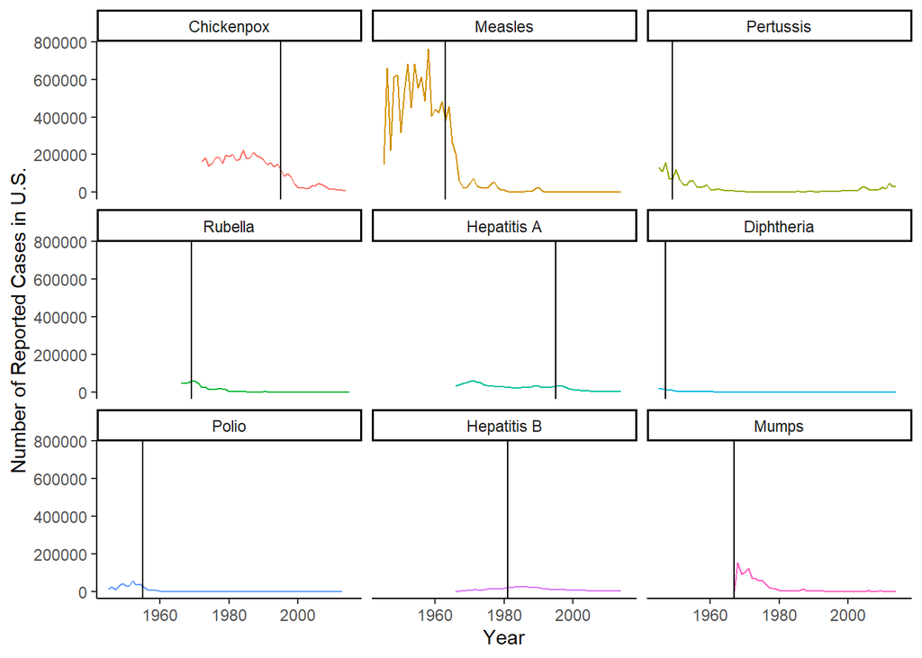

```r
g1 <- ggplot(vac_dat, aes(x = year, y = cases, color = disease))+
  geom_line()+
  theme_classic() +
  theme(legend.position = "none")
g2_fac <- g1 + facet_wrap(~disease)
g2_fac + geom_vline(data = vac_l, aes(xintercept = year)) +
  xlab("Year") +
  ylab("Number of Reported Cases in U.S.")
```

BMB: could improve labeling on y-axis (divide by 100,000 ?)

Log Transformed:

The graph below is the same as the previous one but with the number of cases transformed (log base 10). I found it hard to notice the decrease in the number of reported cases in some of the diseases like Pertussis and Polio because there were less reported cases than Measles.

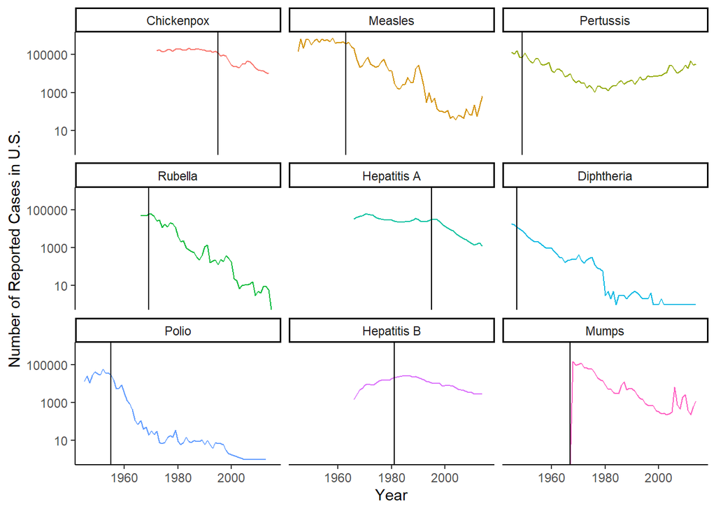

```r
#graph
g1_log <- ggplot(vac_dat, aes(x = year, y = cases, color = disease))+
  geom_line()+
  theme_classic() +
  theme(legend.position = "none")
g2_log_fac <- g1_log + facet_wrap(~disease)
g2_log_fac + geom_vline(data = vac_l, aes(xintercept = year)) +
  scale_y_log10() +
  xlab("Year") +
  ylab("Number of Reported Cases in U.S.")
```

BMB: can probably repeat less code … maybe use a lighter color for vaccine licensing date?